We are going to give a simple demonstration for Poisson process. If you check Wiki, you will find that people actually have several different ways to define Poisson process and all of them essentially are equivalent. However, most of them are quite abstract and mathematical. So, I am going to give the definition of Poisson process by telling you how people simulate a Poisson process. If you know how to generate a Poisson process, you should be clear about what it is.

## Realization of random variable

First, please mention the relationship between **realization** and **random variable**. Suppose $X$ is random variable follows standard normal distribution. Then, $X=3$ is a realization of $X$, and $X=5$ is another realization of $X$. Acutally, the realization of $X$ can be arbitrary real number, since the range of normal distribution is real. Then, we can introduce a more general notation for realization, $x$. So, $X$ is a random variable and $x$ is realization, that is a number.

Consider we have a magic device that can generate random numbers according to standard normal distribution. Then, these generated numbers are realizations of standard normal distribution. Let us do a simple simulation by R. We randomly generated 500 numbers from standard normal distribution as follow. (I only show you the first ten numbers here.)

```r
sn <- rnorm(500, 0, 1)
sn[1:10]
```

```
##  [1] -2.05619540  0.61011000 -0.32788447 -0.01402985  0.23375362  0.55472643
##  [7]  1.39122285  0.44326154  1.81202779  1.42405498
```

Then, you may wonder how we can show these 500 numbers do come from a standard normal distribution. Actually, we can do it by draw a histgram plot for these 500 numbers and draw the density curve (red line) of standard normal distribution. You will find that the distribution of these 500 numbers coincides with the density curve! Again, each of these 500 numbers is a realization of standard normal distribution.

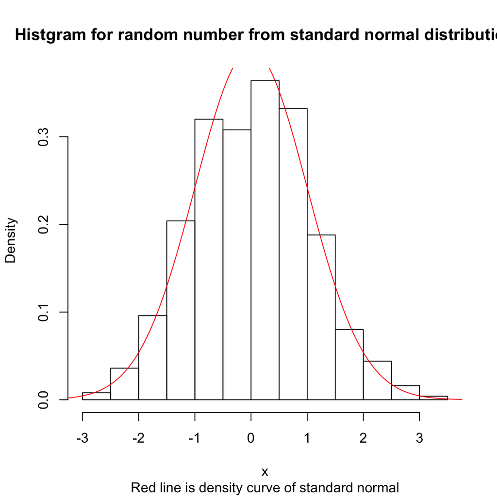

```r
hist(sn, freq = FALSE, main = "Histgram for random number from standard normal distribution",
     sub = "Red line is density curve of standard normal",
     xlab = "x")
lines(seq(-4,4,length.out = 1000), dnorm(seq(-4,4,length.out = 1000)), col = "red")
```

## Construction of Poisson process

I will show how can we simulate a Poisson process here. There are two points I want to mention: 1. we actually simulate a realization of Poisson process, because Poisson process itself is random; 2. Poisson process is defined on infinity time scale and we can only simulate it during a piece of time.

Please remember that the purpose of Poisson process usually is to model the occurance of events. Let us use the outbreak of COVID-19 as an example. Set the event as *a patient is confirmed to be infected by virus*.

First, let us generate 10 random numbers, that will be used as *the time intervals between two consecutive confirmations of infection*, from exponential distribution with rate parameter, $\lambda = 2$. Then, you should know there are actually 10 realizations of exponential distribution with rate 2. Furthermore, we denote these ten numbers as $y_1, y_2, ..., y_{10}$. (They are realizations so we use lower-case and their corresponding random variables are denoted as $Y_1, Y_2, ..., Y_{10}$.)

```r
set.seed(06066)
intervals <- rexp(10, rate = 2)
intervals
```

```
##  [1] 0.50730674 0.06100709 0.83953736 1.84910557 0.02660980 0.37857880
##  [7] 0.36777348 0.24269370 0.13702797 0.16130494
```

Second, let us cumulatively sum them together and we will get *a series of time points when confirmations of infection occur*. These time points actually are $Y_1, Y_1 + Y_2, Y_1 + Y_2 + Y_3, ...$, that is the time of first confirmation, the time of second confirmation, etc.

```r
tps <- cumsum(intervals)
tps
```

```
##  [1] 0.5073067 0.5683138 1.4078512 3.2569568 3.2835666 3.6621454 4.0299188
##  [8] 4.2726125 4.4096405 4.5709454
```

Finally, Poisson process $X(t)$ is defined as the number of confirmed patients by the time $t$. For example, if $t=1.5$, then $X(1.5)$ in this realization is 3, that means by time 1.5, 3 patients are confirmed to be infected.

Let us draw these time points in a time line.

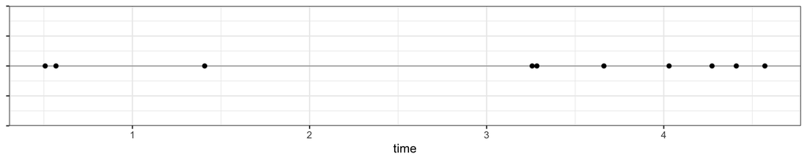

```r
forPlot <- data.frame(events = paste("The", seq_len(length(tps)), "th patient"),
                      time = tps,
                      location = rep(1, length(tps)))
library(ggplot2)
ggplot(forPlot, aes(x = time, y = location)) +
  geom_point() +
  theme_bw() +
  theme(axis.title.y = element_blank(),
        axis.text.y = element_blank()) +
  geom_hline(yintercept = 1, alpha = 0.3)
```

Now, it is time to mention that this is a realization of Poisson process with rate parameter 2. If we reprocess the above algorithm, we will get another realization. For example,

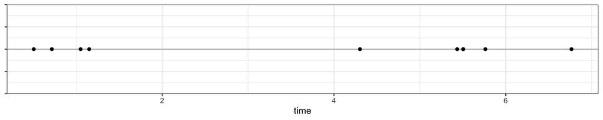

Again, each realization is fixed and Poisson process itself it random. Now, we can demonstrate and understand the definition of Poisson process. Suppose $Y_1, Y_2, Y_3, ... \sim^{i.i.d.} \; Exponential(\lambda)$ and $T_1 = Y_1$, $T_2 = Y_1 + Y_2$, $T_3 = Y_1 + Y_2 + Y_3$, … Then, Poisson process is a counting process defined as
$$X(t) = argmax_i\{T_i \leq t\}.$$

*Two properties*

1. For given time interval with length $\delta$, the number of occurances during this time interval, $N(\delta )$, follows Poisson distribution with parameter $\delta \lambda$.
2. The time interval between two consecutive occurances, $\Delta$, follows exponential distribution with rate parameter $\lambda$.